# article

**Orphan crops as strategic plant genetic resources in Peru: scientific trends and the status of *ex situ* conservation**

Victor-Hugo Baldera-Chapoñan<sup>1,2,3*</sup>, Wagner Meza-Maicelo<sup>1,2,3</sup>, Yoel Diaz-Saucedo<sup>1,3</sup>, Ivan Manrique<sup>4</sup>, German De La Cruz<sup>5</sup>, Aquilino Alvarez-Caceres<sup>6</sup>, Maywa Cecilia Blanco-Zamalloa<sup>6</sup>, Catalina Jimenez-Aguilar<sup>6</sup>, Maria Rosario Elsa Valderrama-Valencia<sup>7</sup>, Angel Mauricio Holguer Mujica Sanchez<sup>8</sup>, Jorge Alberto Condori-Apfata<sup>3</sup>, Jorge Luis Maicelo Quintana<sup>9</sup>, Flavio Lozano-Isla<sup>1,2,3*</sup>.

1 Centro de Investigación e Innovación en Granos y Semillas, Universidad Nacional Toribio Rodríguez de Mendoza de Amazonas (UNTRM), Chachapoyas - Amazonas 01001, Perú..

2 Instituto de Investigación para el Desarrollo Sustentable de Ceja de Selva (INDES-CES), Universidad Nacional Toribio Rodríguez de Mendoza de Amazonas (UNTRM), Chachapoyas - Amazonas 01001, Perú

3 Facultad de Ingeniería y Ciencias Agrarias, Universidad Nacional Toribio Rodríguez de Mendoza de Amazonas (UNTRM), Chachapoyas - Amazonas 01001, Perú.

4 International Potato Center (CIP), Lima, Peru

5 Facultad de Ciencias Agrarias, Universidad Nacional de San Cristóbal de Huamanga (UNSCH), Ayacucho 05000, Peru

6 Universidad Nacional de San Antonio Abad del Cusco (UNSAAC), Cusco, Perú.

7 Universidad Nacional de San Agustín, Arequipa 04001, Peru

8 Universidad Nacional del Altiplano, Puno, Perú

9 Facultad de Ingeniería Zootecnista, Agronegocios y Biotecnología, Universidad Nacional Toribio Rodríguez de Mendoza de Amazonas (UNTRM-A), Chachapoyas, Amazonas 01001, Peru

* Corresponding author: victorhugobalderachaponan@gmail.com; flavio.lozano@untrm.edu.pe

| Author | Email | ORCID |
| --- | --- | --- |
| Victor-Hugo Baldera-Chapoñan | victorhugobalderachaponan@gmail.com | 0009-0003-4321-7103 |
| Wagner Meza-Maicelo | wagner.meza.epg@untrm.edu.pe | 0009-0003-3556-3866 |
| Yoel Diaz-Saucedo | 7576425921@untrm.edu.pe | 0009-0003-9765-136X |
| Ivan Manrique | i.manrique@cgiar.org | 0009-0006-7723-3488 |
| German De La Cruz | german.delacruz@unsch.edu.pe | 0000-0001-7618-799X |
| Aquilino Alvarez-Caceres | aquilino.alvarez@unsaac.edu.pe | 0000-0002-7699-692X |
| Maywa Cecilia Blanco-Zamalloa | maywa.blanco@unsaac.edu.pe | 0000-0002-3927-8769 |
| Catalina Jimenez-Aguilar | catalina.jimenez@unsaac.edu.pe | 0000-0002-1813-7756 |
| Maria Rosario Elsa Valderrama-Valencia | mvalderramav@unsa.edu.pe | 0000-0002-1515-3195 |
| Angel Mauricio Mujica Sanchez | amhmujica@yahoo.com | 0000-0002-7013-8780 |
| Jorge Alberto Condori-Apfata | jorge.condori@untrm.edu.pe | 0000-0001-9270-1733 |
| Jorge Luis Maicelo Quintana | jmaicelo@untrm.edu.pe | 0000-0001-9109-0504 |
| Flavio Lozano-Isla | flavio.lozano@untrm.edu.pe | 0000-0002-0714-669X |

**ABSTRACT**

Orphan crops constitute important plant genetic resources because of their nutritional, agronomic, cultural, and adaptive value, yet their scientific development and *ex situ* conservation remain unevenly documented in Peru. This study aimed to characterize scientific research on selected orphan crops relevant to Peru and assess the status of their reported germplasm collections using a multi-method exploratory-descriptive approach. A bibliometric analysis was conducted on 157 publications indexed in Scopus, retrieved through species-specific searches combining the scientific name of each crop with the term “germplasm”. Scientific productivity, citation patterns, international collaboration networks, keyword occurrence, thematic evolution, and conceptual structure were analyzed. The bibliometric assessment was complemented by a structured questionnaire administered to researchers responsible for germplasm conservation and by institutional records obtained from the Germplasm Bank Information System of the National Institute for Agrarian Innovation. The reported inventory comprised 14,694 accessions distributed across eight departments and representing 10 of the 11 evaluated species; no accessions of *Salvia hispanica* were reported in the collections assessed. *Chenopodium quinoa* showed the highest frequency among crop-specific keywords (47 occurrences) and the largest number of reported accessions (4,194), followed by *Lupinus mutabilis* (3,344) and *Amaranthus caudatus* (2,003). Thematic evolution indicated a shift from research focused on morphological and taxonomic characterization toward studies addressing genetic diversity, molecular characterization, and plant breeding. Institutional differences were observed in conservation modalities, characterization approaches, documentation, and germplasm management. The findings establish a baseline for understanding scientific research and the reported *ex situ* conservation of selected orphan crops in Peru and identify areas where collection documentation, characterization, institutional coordination, and sustainable use could be strengthened.

**Keywords:** agrobiodiversity; bibliometric analysis; conservation; germplasm; plant genetic resources.

# 1 **INTRODUCTION**

Contemporary agricultural systems face challenges arising from population growth, natural resource degradation, biodiversity loss, and the effects of climate change on food production [[1–3]](https://www.zotero.org/google-docs/?7b8bn9). These conditions increase the vulnerability of production systems and compromise their capacity to meet the future demand for nutritious and accessible food [[2,4]](https://www.zotero.org/google-docs/?ddUTVW). Enhancing agrobiodiversity has been recognized as a strategy to strengthen agroecosystem resilience, reduce dependence on a limited number of cultivated species, and promote more sustainable production systems [[5,6]](https://www.zotero.org/google-docs/?UTsTgM). Therefore, harnessing the genetic diversity available in cultivated plants and their wild relatives constitutes an essential component for addressing challenges related to food security and adapting agriculture to changing environmental conditions. .

Orphan crops, also referred to as neglected and underutilized species (NUS) [[7]](https://www.zotero.org/google-docs/?TdD0iB), are plant species that, following prolonged processes of domestication and farmer-driven selection in their regions of origin or naturalization, have remained largely overlooked by scientific research, plant breeding, and agricultural development policies despite their recognized food, nutritional, economic, and cultural value [[8–11]](https://www.zotero.org/google-docs/?9l79MY). The term “orphan” refers to the limited attention these species have received from scientific research, breeding programs, and agricultural development policies rather than to their agronomic importance. These species constitute fundamental resources for local communities because of their high genetic diversity, adaptation to marginal environments, and resilience to biotic and abiotic stresses. Moreover, their status is context-dependent, as a crop may be widely cultivated and commercialized in one region while remaining underutilized or insufficiently studied in another [[10,12]](https://www.zotero.org/google-docs/?SB2JVx)

The growing recognition of the agronomic, nutritional, and environmental characteristics of these crops has promoted their incorporation into international initiatives aimed at diversifying agricultural production and strengthening the resilience of food systems [[13–16]](https://www.zotero.org/google-docs/?T7H5O6). Several studies have documented that these crops possess the capacity to adapt to adverse environmental conditions, tolerate biotic and abiotic stresses, and maintain cultural and historical significance for numerous rural communities [[17–21]](https://www.zotero.org/google-docs/?GgDTGp), representing an important source of genetic diversity that could be harnessed to expand the options available to address the challenges facing contemporary agriculture.

Peru is recognized as a center of origin and diversification for numerous cultivated species, harboring substantial diversity of plant genetic resources associated with different ecological regions and traditional production systems [[22–24]](https://www.zotero.org/google-docs/?Xk7ElE). This diversity has been maintained through historical processes of selection and management developed by local communities, contributing to the conservation of a broad genetic pool [[22]](https://www.zotero.org/google-docs/?QL9VdM). Among the species of interest are arracacha (*Arracacia xanthorrhiza*), cañihua (*Chenopodium pallidicaule*), chia (*Salvia hispanica*), kiwicha (*Amaranthus caudatus*), maca (*Lepidium meyenii*), mashua (*Tropaeolum tuberosum*), oca (*Oxalis tuberosa*), olluco (*Ullucus tuberosus*), quinoa (*Chenopodium quinoa* Willd.), tarwi (*Lupinus mutabilis*), and yacón (*Smallanthus sonchifolius*), which represent an important fraction of Andean agrobiodiversity and have attracted increasing interest because of their nutritional properties, adaptation to diverse environments, and potential to contribute to the diversification of agricultural systems [[14,25,26]](https://www.zotero.org/google-docs/?yokXFQ). However, the level of knowledge and utilization of these resources remains variable among species, highlighting the need to consolidate information that can guide research and conservation efforts.

The conservation of plant genetic resources constitutes a fundamental strategy for safeguarding the genetic diversity required for the development of breeding programs, scientific research, and the adaptation of crops to new environmental conditions [[27–29]](https://www.zotero.org/google-docs/?jyGfth). Among the different strategies available, *ex situ* conservation through germplasm banks plays a central role by enabling the collection, characterization, documentation, regeneration, and maintenance of accessions representative of existing variability. These banks serve as repositories of genetic resources and provide biological material for research, education, and agricultural development activities [[29]](https://www.zotero.org/google-docs/?LDhmcU). Strengthening the technical and institutional capacities dedicated to the management of these collections is essential to ensure the future availability of strategic genetic resources.

At the international level, specific programs have been established for the conservation and sustainable use of plant genetic resources of agronomic importance [[30,28,31]](https://www.zotero.org/google-docs/?74YMD8). However, the effectiveness of germplasm banks depends on factors such as the availability of adequate infrastructure, the implementation of standardized conservation protocols, the existence of efficient documentation systems, and access to trained human resources [[29]](https://www.zotero.org/google-docs/?DALnRx). In the absence of these conditions, collections may face risks associated with the loss of viability of conserved material, unnecessary duplication of efforts, or limited accessibility to the information generated. Therefore, periodic assessments of the status of germplasm banks constitute necessary tools for identifying strengths, limitations, and priority intervention needs.

In Peru, various public and private institutions, universities, and research centers conduct activities related to the conservation of plant genetic resources of agricultural importance. However, information on collections associated with orphan crops remains scattered and, in many cases, has not been systematized or disseminated through scientific publications. Similarly, limited knowledge exists regarding the conditions under which germplasm conservation is carried out, including aspects related to available infrastructure, management procedures, record-keeping systems, and institutional capacities to ensure the sustainability of collections. This situation hinders the development of a comprehensive understanding of the current status of *ex situ* conservation of these genetic resources in the country.

Despite the growing recognition of the potential of orphan crops to contribute to agricultural diversification, food security, and the adaptation of production systems to climate change scenarios [[17,18,20,21]](https://www.zotero.org/google-docs/?7n6W8l), limitations persist regarding the availability and systematization of information on the genetic resources associated with these species in Peru. Existing studies have focused primarily on the agronomic or nutritional characterization of specific crops, whereas research aimed at comprehensively assessing the status of germplasm banks responsible for their conservation remains scarce. Information concerning collection size, conservation methods, available documentation systems, and institutional capacities for germplasm management remains scattered or has not been reported in the scientific literature. This situation hinders the identification of gaps in conservation programs and limits the development of evidence-based national strategies to strengthen the management of plant genetic resources.

Therefore, the present study aimed to: (i) conduct a bibliographic analysis to identify and characterize orphan crops reported in Peru; (ii) assess the current status of germplasm banks involved in the conservation of these crops through surveys administered to the responsible institutions; and (iii) diagnose the conservation and management conditions of these germplasm banks, with the aim of generating information to support the development of strategies for strengthening the conservation of plant genetic resources of current and potential importance to Peruvian agriculture.

# 2 **RESULTS AND DISCUSSION**

Peru possesses substantial crop genetic diversity that is conserved in germplasm collections maintained by research institutions and other organizations. The crops examined in this study include species that may provide useful genetic variation for breeding under changing environmental conditions. Improving their characterization and documentation could facilitate the identification of accessions with traits relevant to adaptation, productivity, and other breeding objectives. Digital management of accession-level information would make these resources more accessible for research and could strengthen their use in breeding programs. Better coordination among institutions would facilitate the exchange of information and genetic material and could contribute to the longer-term use of Peru’s crop genetic resources in efforts related to climate adaptation and food security.

## 2.1 *The Landscape of Orphan Crops*

### 2.1.1 *Analysis of Global Scientific Production*

The analysis of annual scientific production, based on the aggregation of 157 records indexed in Scopus, revealed a temporal pattern characterized by an initial phase of low productivity, followed by a progressive increase in the number of publications and variable citation dynamics (Figure 1). During the period from 1989 to the late 1990s, scientific production remained low, ranging from one to two publications per year, whereas citation counts were relatively high in specific years, such as 1989 and 1998, indicating the presence of contributions with substantial cumulative impact. From the early 2000s onward, a gradual expansion in scientific production was observed, reaching three to six publications annually during the 2000s, accompanied by an increase in citations, with a pronounced peak in 2007 associated with highly influential documents in the field.

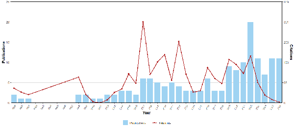

Figure 1: Annual trends in scientific production (light blue bars, left axis) and annual citation volume (red line, right axis) on orphan crops during the 1989–2026 period.

### 2.1.2 *Scientific Production and Collaboration Networks*

The international co-authorship network (≥5 collaborations; Figure 2) comprised 16 countries organized into five collaboration clusters. Only countries with at least five international collaborations were included in the analysis. Cluster 1 (red) consisted of the United States, Peru, Colombia, Bolivia, Belgium, and Denmark. Cluster 2 (green) included India, Germany, Italy, and Chile. Cluster 3 (blue) comprised China and Argentina. Cluster 4 (purple) included Spain and Mexico, whereas Cluster 5 (yellow) consisted of Ecuador and the Netherlands. The distribution of nodes showed extensive connectivity among the clusters, with multiple links between countries belonging to different collaboration groups. This structure indicates the formation of an international scientific network focused on the study of native and underutilized crops, in which cooperation between countries with abundant plant genetic resources and those with greater technological capacity facilitates knowledge generation on the conservation, characterization, and utilization of agricultural diversity.

The United States and Peru exhibited the largest nodes and the highest number of links within the network, followed by Colombia, Spain, India, and Germany. Peru’s central position within the network is associated with its importance as a center of origin and diversification of cultivated species, harboring extensive genetic variability of Andean crops such as *Amaranthus caudatus, Chenopodium pallidicaule, Chenopodium quinoa, Lepidium meyenii, Lupinus mutabilis, Oxalis tuberosa, Smallanthus sonchifolius, Tropaeolum tuberosum, and Ullucus tuberosus* (Figure 2). This diversity has been conserved through traditional management and selection practices carried out by Andean communities, constituting an important source of genetic resources for research on environmental adaptation, nutritional quality, and plant breeding [[32,33]](https://www.zotero.org/google-docs/?Uxto6t).

The United States established direct collaborations with Peru, Colombia, Bolivia, Belgium, Germany, and Spain, whereas Peru recorded links with the United States, Colombia, Bolivia, Belgium, Denmark, and Ecuador (Figure 2). The strong connection between the two countries reflects the complementarity between the availability of native germplasm and scientific capacity for conducting advanced studies in genetics, biotechnology, nutritional analysis, and agronomic evaluation. Andean crops have gained increasing international relevance because of their capacity to adapt to restrictive environmental conditions and their potential to contribute to the diversification of food systems under scenarios associated with climate change and food security [[34–36,20,37]](https://www.zotero.org/google-docs/?xC4FPo)

The participation of European countries such as Belgium, Denmark, Germany, Italy, Spain, and the Netherlands within the network indicates growing interest in crops outside conventional agricultural systems. In these countries, research on quinoa, amaranth, tarwi, and other Andean crops has been associated with the identification of functional properties, nutritional composition, bioactive metabolites, and production alternatives for specialized markets [[36,38–40]](https://www.zotero.org/google-docs/?wFz19m). The incorporation of advanced analytical tools and multidisciplinary approaches has broadened the understanding of the biological and agronomic value of these resources, facilitating their integration into international research and conservation programs.

Spain presented connections with the United States, Germany, Mexico, Colombia, and Ecuador, whereas Germany was linked to India, Italy, Chile, the United States, and Spain, demonstrating the participation of countries with established capacities in genetic, technological, and food research (Figure 2). The presence of India and China within the network reflects growing international interest in alternative crops with relevant nutritional characteristics and the capacity to adapt to diverse environmental conditions, considering these countries’ experience in the conservation and utilization of plant genetic resources. Ecuador maintained links with Peru, Spain, Denmark, and the Netherlands, whereas China and Argentina formed an independent cluster with a connection between the two countries, and Mexico showed a primarily strong relationship with Spain. This structure reflects the expansion of research on Andean crops and underutilized species through regional and international collaboration networks; however, scientific production remains concentrated on species with greater global recognition, such as quinoa, while other native crops, including mashua, ulluco, arracacha, maca, and yacon, have a lower presence in the scientific literature despite their agricultural, ecological, and nutritional importance.

[figure not shown]

Figure 2: International scientific collaboration network based on country co-authorship in research on orphan crops (1989-2026).

[figure not shown]

Figure 3: Distribution of scientific production by corresponding author’s country and type of collaboration (single-country [SCP] and multiple-country [MCP]) in research on orphan crops.

The author co-authorship network (≥3 collaborations; Figure 4) identified a cluster comprising Maughan P. J., Jellen E. N., Stevens M. R., Fairbanks D. J., Coleman C. E., and Bonifacio A., whose studies focused on the characterization and conservation of plant genetic resources of Andean crops. Publications produced by this group addressed the genetic diversity of *Chenopodium quinoa* Willd., *Chenopodium pallidicaule*, and *Amaranthus caudatus* germplasm through the use of SSR and SNP molecular markers, the development of genetic maps, genome sequencing, and the evaluation of populations for plant breeding [[41–43,39,40,44,19]](https://www.zotero.org/google-docs/?OFOGLg). The cluster’s studies also included research on downy mildew resistance, seed protein characterization, and salinity stress responses in tolerant quinoa accessions [[45,46]](https://www.zotero.org/google-docs/?Be9Vsy). The high frequency of collaboration among these authors reflects a research line focused on the study of genetic diversity and the utilization of plant genetic resources in orphan crops (Figure 4).

[figure not shown]

Figure 4: Co-authorship network among authors (≥3 collaborations). Node size is proportional to the number of publications by each author, whereas links represent the frequency of collaboration among them.

### 2.1.3 *Citation analysis*

The ten most cited documents identified during the study period are presented in Table 1, with citation counts ranging from 77 to 154. The most cited article was *Genetic variability and interrelationships among various morphological and quality traits in quinoa (Chenopodium quinoa Willd.)* [[47]](https://www.zotero.org/google-docs/?Dn6JD0) with 154 citations, followed by *Extending the range of an ancient crop, Salvia hispanica L.—a new ω3 source* [[48]](https://www.zotero.org/google-docs/?PiuHvc), with 114 citations, and *Sampling strategy for a core collection of Peruvian quinoa germplasm* [[49]](https://www.zotero.org/google-docs/?k3feda), with 108 citations. The documents ranked fourth to sixth evaluated the genetic diversity of quinoa germplasm collections and the implications of seed exchange for genetic conservation, accumulating between 89 and 103 citations [[50–52]](https://www.zotero.org/google-docs/?wx0uJQ). The articles ranked seventh to tenth addressed the nutritional and functional composition of quinoa genotypes cultivated under contrasting environments, amino acid profiles of quinoa cultivated in Washington, the nutritional and functional diversity of vegetable amaranth (*Amaranthus tricolor* L.), and the morphological diversity of quinoa germplasm cultivated under arid lowland conditions, receiving between 77 and 82 citations [[53–56]](https://www.zotero.org/google-docs/?7eiKff) (Table 1).

Table 1: Top 10 Most-Cited Documents on Orphan Crops and Germplasm Banks.

| Rank | Title | Author | Source | TC | Document |
| --- | --- | --- | --- | --- | --- |
| 1 | Genetic variability and interrelationship among various morphological and quality traits in quinoa (*Chenopodium quino*a Willd.) | Bhargava A;Shukla S;Ohri D | Field Crops Research | 154 | Article |
| 2 | Extending the range of an ancient crop, *Salvia hispanica* L.-a new ω3 source | Jamboonsri W;Phillips Td;Geneve Rl;Cahill Jp;Hildebrand Df | Genetic Resources And Crop Evolution | 114 | Article |
| 3 | Sampling strategy for a core collection of peruvian quinoa germplasm | Ortiz R;Ruiz-Tapia En;Mujica-Sanchez A | Theoretical And Applied Genetics | 108 | Article |
| 4 | Assessment of genetic diversity patterns in chilean quinoa (*Chenopodium quinoa* willd.) germplasm using multiplex fluorescent microsatellite markers | Fuentes Ff;Martinez Ea;Hinrichsen Pv;Jellen En;Maughan Pj | Conservation Genetics | 103 | Article |
| 5 | Assessment of genetic diversity in the usda and cip-fao international nursery collections of quinoa (*Chenopodium quinoa* Willd.) using microsatellite markers | Christensen Sa;Pratt Db;Pratt C;Nelson Pt;Stevens Mr;Jellen En;Coleman Ce;Fairbanks Dj;Bonifacio A;Maughan Pj | Plant Genetic Resources: Characterisation And Utilisation | 96 | Article |
| 6 | Implications of farmers’ seed exchanges for on-farm conservation of quinoa, as revealed by its genetic diversity in chile | Fuentes Ff;Bazile D;Bhargava A;Martínez Ea | Journal Of Agricultural Science | 89 | Article |
| 7 | Influence of contrasting environments on seed composition of two quinoa genotypes: Nutritional and functional properties | Miranda M;Vega-Gálvez A;Martínez Ea;López J;Marín R;Aranda M;Fuentes F | Chilean Journal Of Agricultural Research | 82 | Article |
| 8 | Seed composition and amino acid profiles for quinoa grown in washington state | Craine Eb;Murphy Km | Frontiers In Nutrition | 81 | Article |
| 9 | Diversity in phenotypic and nutritional traits in vegetable amaranth (*Amaranthus tricolor*), a nutritionally underutilised crop | Shukla S;Bhargava A;Chatterjee A;Pandey Ac;Mishra Bk | Journal Of The Science Of Food And Agriculture | 80 | Article |
| 10 | Morphological analysis of quinoa germplasm grown under lowland desert conditions | Fuentes F;Bhargava A | Journal Of Agronomy And Crop Science | 77 | Article |

∗ Source: Authors’ own elaboration based on data exported from Scopus.

### 2.1.4 *Keyword Analysis*

To analyze the conceptual structure of research on genetic resources and the breeding of Andean crops, author keywords were used to identify the most frequently occurring terms, recognize the main thematic trends, and assess the evolution of research lines.

The keyword cloud (Figure 5) revealed the predominance of terms related to germplasm (53 occurrences), *Chenopodium quinoa* (47), genetic diversity (35), and plant breeding (18), highlighting the importance of the conservation, characterization, and utilization of genetic resources in Andean crops. The high frequency of the term germplasm reflects the fundamental role of plant genetic resource collections as sources of variability for studies of genetic diversity, genotype selection, and the development of improved materials [[57,58]](https://www.zotero.org/google-docs/?GayqsR). he presence of terms such as genetic marker (14), population structure (11), genetic variability (10), and molecular markers (6) indicates the incorporation of genomic tools for assessing genetic relationships and identifying diversity patterns in plant populations. Likewise, the frequency of *Amaranthus caudatus* (16), *Amaranthus hypochondriacus* (6), *Oxalis tuberosa* (6), and *Solanum tuberosum* (5) reflects scientific interest in Andean species of agricultural importance and potential for production diversification. The occurrence of terms such as morphology, genotype, protein, grain yield, and multivariate analysis indicates the integration of phenotypic evaluations and statistical tools for the characterization of accessions and the identification of materials with favorable agronomic attributes.

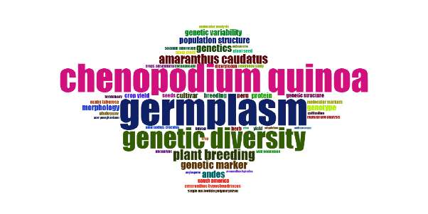

Figure 5: Keyword cloud based on co-occurrence frequency in research on orphan crops (1989–2026).

The thematic trend analysis revealed the temporal evolution of keywords associated with this research field, highlighting a clear transition from morphological and regional studies toward molecular approaches and advanced plant breeding. The initial stages focused on basic geographical and taxonomic identification, with terms such as *Chenopodium*, Peru, *Amaranthus cruentus*, Bolivia, *Amaranthus hypochondriacus*, and South America reaching their highest frequency between 2005 and 2007 (Figure 6). This trend reflects the initial interest in documenting the biological diversity and distribution of Andean species, constituting a fundamental stage for establishing reference collections and understanding the diversity available within plant genetic resources [[59]](https://www.zotero.org/google-docs/?jLJTQz). Subsequently, scientific interest shifted toward basic phenotypic, morphological, and agronomic characterization through concepts such as *Oxalis tuberosa*, morphology, phenotype, and cultivar, which consolidated their presence toward the end of the 2000s, demonstrating the importance of observable traits as a basis for the preliminary classification and selection of genetic materials [[34,60–62]](https://www.zotero.org/google-docs/?MPg0q4)

The period from 2010 to 2015 marked the phase of greatest thematic volume and consolidation, led by research on genetic resources and key Andean crops, with *germplasm* showing the highest cumulative frequency, followed by *Chenopodium quinoa*, *genetic diversity*, the Andes, *Amaranthus caudatus*, wild populations, phylogeny, and genetic variability. This pattern indicates a shift toward the conservation, evaluation, and utilization of genetic diversity as a strategy to strengthen plant breeding programs, particularly for species adapted to marginal environments and of importance for food security (Figure 6). From 2016 onward, the research trend adopted a more analytical profile through the use of molecular, bioinformatic, and statistical tools represented by terms such as genotype, molecular analysis, multivariate analysis, and population structure, reflecting the incorporation of genomic technologies to characterize the genetic organization of populations and facilitate marker-assisted selection [[37,56,63–66]](https://www.zotero.org/google-docs/?Sg5zMA). Recent studies have focused directly on yield optimization and applied biotechnology, positioning terms such as genetic structure, genetics, plant breeding, grain yield, yield, breeding, and molecular markers as current and emerging research fronts, demonstrating an increasing integration of genomic information with phenotypic evaluation for the development of superior cultivars [[67]](https://www.zotero.org/google-docs/?4KZUCS).

[figure not shown]

Figure 6: Temporal evolution of trending topics based on the annual frequency and period of occurrence of keywords.

The longitudinal thematic evolution map tracks the trajectory, branching, and consolidation of the cognitive structure of research across four specific periods between 1989 and 2026 (Figure 7). The initial period (1989-2010) established the scientific foundation through phenotypic and taxonomic characterization, represented by the nodes *genetic variability*, *germplasm*, *phenotype*, *Chenopodium quinoa*, *dicotyledon*, and *Amaranthus caudatus*, reflecting interest in describing biological diversity, establishing taxonomic relationships, and generating a basis for the conservation of plant genetic resources [[68,69,41,49,70,71]](https://www.zotero.org/google-docs/?w6mQcJ). This pattern is consistent with the early stages of research on plant genetic resources, in which morphological characterization and the establishment of collections provided the foundation for documenting and conserving genetic diversity. The subsequent period (2011–2019) showed convergence toward the central theme of *Chenopodium quinoa*, incorporating research lines associated with *genetics*, *protein*, *genotype*, *cultivation*, and *genetic differentiation*, indicating a transition toward studies aimed at understanding the genetic structure, nutritional composition, and agronomic adaptation of evaluated materials through advanced characterization tools. This evolution reflects the growing scientific interest in quinoa as a strategic crop because of its high nutritional value, broad environmental adaptability, and potential contribution to food security, promoting the incorporation of molecular and genetic tools into germplasm studies [[72–77]](https://www.zotero.org/google-docs/?eUU5hY).

The stabilization period (2020-2023) transformed accumulated knowledge into applications in plant breeding, highlighting the axis of *plant breeding* together with *germplasm*, *germplasm characterization*, and the geographical context of the Andes, demonstrating a stronger orientation toward the utilization of genetic diversity for the development of superior materials. The persistence of the term *Andes* reaffirms the importance of this region as one of the major centers of origin and diversification of native crops, where genetic richness continues to provide the basis for breeding programs [[78–83]](https://www.zotero.org/google-docs/?LOn4uY).The current period (2024-2026) demonstrates the consolidation of the research field around three dominant macrothemes: *germplasm*, *Chenopodium quinoa*, and *genetic diversity*, in which genetic, morphological, and plant breeding approaches converge, reflecting a trend toward integrated strategies for the conservation and utilization of genetic resources through molecular and phenotypic tools. This convergence demonstrates the increasing maturity of the research field, which is oriented toward integrating genomic, phenotypic, and agronomic information to optimize conservation, expand the utilization of genetic diversity, and strengthen the development of varieties adapted to climate change and sustainable agricultural scenarios [[61,66,84,85]](https://www.zotero.org/google-docs/?skFBRM)

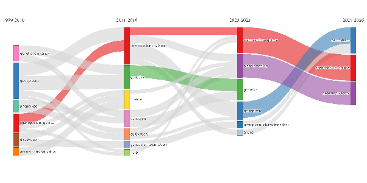

Figure 7: Longitudinal thematic evolution of research on orphan crops structured into four analytical periods.

The thematic map reveals the intellectual structure of research by classifying clusters according to their degree of relevance (centrality) and development (density) (Figure 8). Motor themes exhibit a high level of development and importance within the scientific field, consolidating around agricultural production and optimization through terms such as *cultivation*, *plant breeding*, and *crop yield*, reflecting an increasing orientation toward the application of genetic knowledge to the development of materials with greater production potential. Basic themes constitute the fundamental core of the discipline, with high centrality but lower development, and are centered on *Chenopodium quinoa*, *germplasm*, and *genetic diversity*, demonstrating that the conservation and characterization of plant genetic resources remain essential pillars of research on Andean crops. Niche themes correspond to highly specialized research lines with lower overall interaction, focusing on *genetic differentiation*, *molecular analysis*, and *genetic analysis*, reflecting the incorporation of advanced tools to understand the genetic structure and relationships among populations (Figure 8). Conversely, emerging or declining themes exhibit lower centrality and density, encompassing general genetic studies associated with species such as *Solanum tuberosum* and *Oxalis tuberosa*, whereas intermediate nodes related to *genotype* and *genetic variability* indicate a transition toward research lines with greater applicability to plant breeding. The presence of *Amaranthus caudatus*, proteins, and wild populations reflects the continuity of studies aimed at understanding the biological diversity and functional attributes of Andean species of agricultural importance. This thematic distribution demonstrates an evolution from research focused on the conservation and characterization of genetic diversity toward approaches oriented toward the utilization of germplasm through molecular tools and plant breeding strategies, consistent with current trends in plant genetic resource research, where the integration of conservation, characterization, and sustainable utilization constitutes a key component for strengthening food security and crop adaptation to climate change.

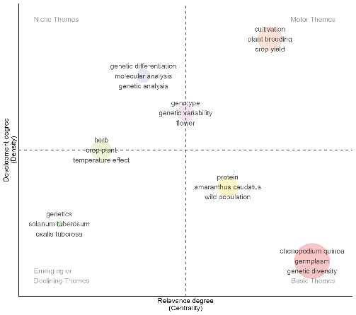

Figure 8: Thematic map of the conceptual structure based on centrality (degree of relevance) and density (degree of development) indicators during the period 1989-2026.

## 2.2 *The State of Germplasm Banks in Peru*

To identify the distribution of germplasm collections of orphan crops in Peru, information was compiled on the institutions responsible for their conservation, their geographical location, the number of accessions recorded for each species, the conservation strategies employed, and the characterization status of the collections. In total, 14,694 reported accession records corresponding to 10 of the 11 evaluated species were recorded across 11 institutions located in eight departments of Peru: Cusco, Puno, Lima, Cajamarca, Junín, Amazonas, Ayacucho, and Arequipa (Figure 9). The geographical distribution was markedly heterogeneous, with collections concentrated in Cusco, Puno, and Lima. Cusco accounted for 7,745 accessions, followed by Puno with 3,529 and Lima with 1,902, whereas Cajamarca, Junín, Ayacucho, Amazonas, and Arequipa recorded 602, 436, 270, 198, and 12 accessions, respectively.

In Cusco, the collections were concentrated at the Universidad Nacional de San Antonio Abad del Cusco (UNSAAC) and the Estación Experimental Agraria Andenes (EEA-Andenes), which jointly accounted for 7,745 accessions. EEA-Andenes recorded 941 accessions of *Oxalis tuberosa*, 224 of *Tropaeolum tuberosum*, 192 of *Ullucus tuberosus*, and 20 records of *Chenopodium quinoa*, whereas UNSAAC held 6,368 accessions, with a high representation of *Lupinus mutabilis*, *Amaranthus caudatus*, and *Chenopodium quinoa* (Figure 9). The high institutional concentration observed in Cusco may be associated with the long-standing involvement of regional institutions in the collection, characterization, and conservation of Andean plant genetic resources. The size of these collections, by itself, does not allow a greater degree of genetic diversity to be inferred, because the number of accessions provides no information about redundancy, geographical provenance, or genetic differentiation.

Puno comprised 3,529 accessions conserved at the Estación Experimental Agraria Illpa (EEA-Illpa) and the Universidad Nacional del Altiplano (UNA-Puno). *Chenopodium quinoa* was the predominant species, with 2,233 accessions across both institutions, followed by *Chenopodium pallidicaule* and *Lupinus mutabilis*. The high representation of Andean species in the collections from Puno is consistent with the importance of the region as an area for the cultivation and conservation of high-Andean plant genetic resources. Lima recorded 1,902 accessions, all concentrated at the International Potato Center (CIP), where *Oxalis tuberosa*, *Ullucus tuberosus*, and *Tropaeolum tuberosum* predominated. The size of the Lima collection indicates that the geographical distribution of genebanks does not depend exclusively on the agroecological distribution of crops but is also influenced by the location of institutions with specialized infrastructure for conservation, documentation, and research.

The departments of Cajamarca, Junín, Amazonas, Ayacucho, and Arequipa had considerably smaller collections. Cajamarca recorded 602 accessions, Junín 436, Ayacucho 270, Amazonas 198, and Arequipa 12 (Figure 9). These differences should not be interpreted as evidence of lower genetic richness or diversity in these regions, because the size of an *ex situ* collection depends on the history of collecting expeditions, institutional objectives, infrastructure availability, and the capacity to regenerate and maintain conserved materials. The limited representation of some regions may more appropriately indicate restricted *ex situ* coverage and support the need for targeted assessments to identify geographical and taxonomic gaps.

At the national scale, *Chenopodium quinoa* had the highest representation, with 4,194 accessions, followed by *Lupinus mutabilis* with 3,344, *Oxalis tuberosa* with 2,152, and *Amaranthus caudatus* with 2,003. *Ullucus tuberosus*, *Chenopodium pallidicaule*, *Tropaeolum tuberosum*, *Smallanthus sonchifolius*, *Arracacia xanthorrhiza*, and *Lepidium meyenii* recorded 998, 613, 610, 318, 284, and 178 accessions, respectively (Figure 9). The greater representation of *C. quinoa*, *L. mutabilis*, and *A. caudatus* is consistent with the historical importance of these species within Andean agricultural systems and their inclusion in conservation and characterization programs. Nevertheless, the number of accessions should be distinguished from the genetic diversity actually represented, because extensive collections may contain redundant materials, whereas smaller collections may conserve a substantial proportion of the variability present within particular populations. The *ex situ* conservation represented by this inventory constitutes only a fraction of the agrobiodiversity present in Peru. A proportion of the diversity of Andean crops continues to be managed by farmers and communities through *in situ* conservation systems, where populations are subjected to dynamic processes of selection, exchange, and adaptation. Interpretation of the national inventory therefore requires integration of information on geographical provenance, morphological and molecular characterization, redundancy among collections, and conservation conditions. The results identify an institutional and taxonomic concentration of conserved germplasm and provide a basis for guiding future activities related to exploration, collection, characterization, and strengthening of collections with limited representation.

[figure not shown]

Figure 9: Geographical distribution and biological representativeness of orphan crop accessions conserved in institutional germplasm banks in Peru. Regional coloring indicates the ranges of accession density stored. For each department analyzed, the repository institutions and species composition are detailed.

The distribution of conservation modalities was consistent with the biological characteristics and propagation systems of the species represented in the collections. Seed conservation was used predominantly for materials maintained as seeds, whereas field and *in vitro* conservation were particularly relevant for vegetatively propagated crops such as *Oxalis tuberosa*, *Ullucus tuberosus*, *Tropaeolum tuberosum*, and *Smallanthus sonchifolius*. The simultaneous use of complementary conservation strategies can provide greater flexibility for maintaining germplasm and can contribute to the security of collections when individual conservation systems are affected by biological, technical, or infrastructural constraints. This interpretation should be considered within the framework of internationally recognized standards for genebank management.

The predominance of phenotypic characterization indicates that morphological and agronomic information remains the principal basis for documenting the evaluated collections. This information is essential for distinguishing materials, documenting phenotypic variation, and identifying traits of potential agronomic interest. The incorporation of genomic characterization provides a complementary basis for assessing genetic variation and relationships among accessions, whereas biochemical characterization can contribute information on nutritional and functional traits. The combined application of these approaches may increase the analytical value and potential utilization of germplasm collections for breeding, conservation planning, and the identification of materials with traits of agricultural or nutritional interest. The current distribution of characterization approaches also indicates that the level of characterization remains heterogeneous among institutions, suggesting that future efforts should prioritize collections for which accession-level phenotypic, genomic, and biochemical information remains limited.

Table 2: Conservation status, characterization methods, and number of accessions of orphan crops maintained in institutions across different regions of Peru.

| Region | Genbank/Institution | Species | Germplasm Collection | Accessions (n) | Characterization Performed | Conservation Method | Year | Reference |
| --- | --- | --- | --- | --- | --- | --- | --- | --- |
| Amazonas | Estación Experimental Agraria Amazonas | *Lupinus mutabilis* | Accessions | 2 | Phenotypic | Field | June 2026 | [[86]](https://www.zotero.org/google-docs/?rNCEQV) |
|  | Universidad Nacional Toribio Rodriguez de Mendoza | *Tropaeolum tuberosum* |  | 10 | Phenotypic, Biochemical | Seed | June 2026 | Survey |
|  |  | *Ullucus tuberosus* |  | 10 | Phenotypic, Biochemical | Seed | June 2026 |  |
|  |  | *Amaranthus caudatus* |  | 5 | Phenotypic | Seed | June 2026 |  |
|  |  | *Oxalis tuberosa* |  | 10 | Phenotypic, Genomic | Seed | June 2026 |  |
|  |  | *Chenopodium quinoa* |  | 161 | Phenotypic, Genomic | Seed and Field | June 2026 |  |
| Arequipa | Universidad Nacional de San Agustín de Arequipa | *Chenopodium quinoa* | Accessions | 10 | Phenotypic, Genomic | Seed | June 2026 |  |
|  |  | *Lupinus mutabilis* |  | 2 | Phenotypic | Seed | June 2026 |  |
| Ayacucho | Universidad Nacional de San Cristóbal de Huamanga | *Chenopodium quinoa* | Accessions | 250 | Phenotypic, Genomic | Seed | June 2026 |  |
|  |  | *Chenopodium pallidicaule* |  | 10 |  | Seed | June 2026 |  |
|  |  | *Lupinus mutabilis* |  | 10 |  | Seed | June 2026 |  |
| Cajamarca | Estación Experimental Agraria Baños del Inca | *Smallanthus sonchifolius* | Accessions | 214 | Phenotypic | Field and in vitro | June 2026 | [[86]](https://www.zotero.org/google-docs/?G7jc96) |
|  |  | *Amaranthus caudatus* |  | 388 | Phenotypic | Seed and Field | June 2026 |  |
| Cusco | Estación Experimental Agraria Andenes | *Tropaeolum tuberosum* | Accessions | 224 | Phenotypic | Field and in vitro | June 2026 |  |
|  |  | *Oxalis tuberosa* |  | 941 | Phenotypic | Field and in vitro | June 2026 |  |
|  |  | *Chenopodium quinoa* | Varieties | 20 | Phenotypic | Field | June 2026 |  |
|  |  | *Ullucus tuberosus* | Accessions | 192 | Phenotypic | Field and in vitro | June 2026 |  |
|  | Universidad Nacional de San Antonio Abad del Cusco | *Chenopodium quinoa* | Accessions | 1520 | Phenotypic | Seed | June 2026 | Survey |
|  |  | *Lupinus mutabilis* |  | 2700 | Phenotypic | Seed | June 2026 |  |
|  |  | *Amaranthus caudatus* |  | 1600 | Phenotypic | Seed and Field | June 2026 |  |
|  |  | *Tropaeolum tuberosum* |  | 100 | Phenotypic | Field | June 2026 |  |
|  |  | *Ullucus tuberosus* |  | 200 | Phenotypic | Field | June 2026 |  |
|  |  | *Oxalis tuberosa* |  | 200 | Phenotypic | Field | June 2026 |  |
|  |  | *Arracacia xanthorrhiza* |  | 7 | Phenotypic | Field | June 2026 |  |
|  |  | *Smallanthus sonchifolius* |  | 41 | Phenotypic | Field | June 2026 |  |
| Junín | Estación Experimental Agraria Santa Ana | *Lepidium meyenii* | Accessions | 21 | Phenotypic | Seed and Field | June 2026 | [[86]](https://www.zotero.org/google-docs/?u06KOp) |
|  |  | *Arracacia xanthorrhiza* |  | 235 | Phenotypic | Field | June 2026 |  |
|  |  | *Lupinus mutabilis* |  | 180 | Phenotypic | Seed and Field | June 2026 |  |
| Lima | Centro Internacional de la Papa | *Tropaeolum tuberosum* | Accessions | 216 | Phenotypic, Genomic | Field and in vitro | June 2026 | Survey |
|  |  | *Ullucus tuberosus* |  | 548 | Phenotypic, Genomic | Field and in vitro | June 2026 |  |
|  |  | *Lepidium meyenii* |  | 157 |  | Seed | June 2026 |  |
|  |  | *Oxalis tuberosa* |  | 881 | Phenotypic, Biochemical | Field and in vitro | June 2026 |  |
|  |  | *Arracacia xanthorrhiza* |  | 42 | Phenotypic, Biochemical | Field and in vitro | June 2026 |  |
|  |  | *Smallanthus sonchifolius* |  | 58 | Phenotypic, Genomic, Biochemical | Field and in vitro | June 2026 |  |
| Puno | Estación Experimental Agraria Illpa | *Chenopodium quinoa* | Accessions | 1383 | Phenotypic | Field | June 2026 | [[86]](https://www.zotero.org/google-docs/?Upuske) |
|  |  | *Chenopodium pallidicaule* |  | 253 | Phenotypic | Field | June 2026 |  |
|  | Universidad Nacional del Altiplano | *Chenopodium quinoa* | Accessions | 850 | Phenotypic, Biochemical | Seed and Field | June 2026 | Survey |
|  |  | *Tropaeolum tuberosum* |  | 60 | Phenotypic | Field | June 2026 |  |
|  |  | *Ullucus tuberosus* |  | 48 | Phenotypic | Field | June 2026 |  |
|  |  | *Chenopodium pallidicaule* |  | 350 | Phenotypic, Biochemical | Seed and Field | June 2026 |  |
|  |  | *Amaranthus caudatus* |  | 10 |  | Seed and Field | June 2026 |  |
|  |  | *Oxalis tuberosa* |  | 120 | Phenotypic | Field | June 2026 |  |
|  |  | *Lupinus mutabilis* |  | 450 | Phenotypic, Biochemical | Seed and Field | June 2026 |  |
|  |  | *Smallanthus sonchifolius* |  | 5 |  | Field | June 2026 |  |

**Note.** Information collected through institutional surveys and supplemented with official records from the germplasm banks of the National Institute of Agrarian Innovation (INIA).

## 2.3 *Challenges for Conservation*

Insufficient financial resources constitute one of the main limitations to the conservation and sustainable utilization of plant genetic resources, particularly for collections of orphan and underutilized crops (Figure 10). Germplasm banks require sustained investment in the storage, periodic regeneration, morphological and molecular characterization, accession documentation, and maintenance of specialized infrastructure. Budgetary constraints have been recognized as a recurrent challenge in national and international conservation programs, affecting institutional capacity to ensure the long-term conservation and effective access to germplasm. Inadequate infrastructure increases the vulnerability of biological collections, while the loss of genetic diversity limits opportunities for developing materials adapted to emerging production and climatic scenarios.

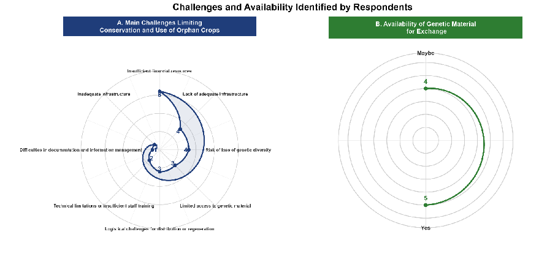

Institutional willingness to exchange germplasm represents a fundamental element for strengthening national and international networks for the conservation and utilization of plant genetic resources. The exchange of genetic material facilitates scientific research, breeding programs, and the expansion of the genetic base available for species with agronomic and nutritional potential. Modern germplasm banks play a central role in the safe and regulated mobilization of plant genetic resources, promoting cooperation among institutions and access to materials of interest for sustainable agriculture. The high level of willingness reported by the participating institutions highlights opportunities to consolidate collaborative mechanisms aimed at the characterization, regeneration, and conservation of existing collections. Strengthening the technical and financial capacities of germplasm banks is therefore essential to maximize the utilization of conserved material and ensure its availability for future generations and for agricultural research and development programs.

## 2.4 *Limitations and perspectives*

This study provides a comprehensive overview of the state of scientific research and germplasm banks for orphan crops in Peru, although limitations should be acknowledged. The bibliometric analysis was based exclusively on the Scopus database; therefore, publications indexed in other bibliographic sources were not included. Information on germplasm banks was collected from the main institutions responsible for the conservation of plant genetic resources in the country; however, other entities may maintain orphan crop collections whose information was not documented or made available during the study period. It was not possible to determine the extent of duplication among conserved collections because of the lack of standardized information and an integrated national database capable of comparing accessions maintained by different institutions.

This study constitutes the first national assessment to integrate information on scientific production and the main germplasm collections of orphan crops in Peru, establishing a baseline for future initiatives aimed at expanding the national inventory, strengthening collection documentation, and promoting greater integration among institutions involved in the conservation of plant genetic resources. The implementation of a national platform for information exchange among germplasm banks, complemented by molecular characterization of the collections, would facilitate the identification of duplicate accessions, optimization of storage capacity, and more efficient allocation of conservation resources. Coordinating these efforts would accelerate the identification of genotypes with promising agronomic traits and strengthen the conservation, management, and utilization of plant genetic resources for food and agriculture in Peru.

# 3 **CONCLUSIONS**

The bibliometric analysis revealed sustained growth in research on orphan crops of relevance to Peru, with *Chenopodium quinoa* emerging as the central focus of scientific production, followed by species such as *Amaranthus caudatus*, *Lupinus mutabilis*, and *Chenopodium pallidicaule*. The thematic evolution showed a transition from studies focused on morphological characterization and germplasm conservation toward research addressing genetic diversity, plant breeding, and the integration of molecular tools, reflecting the increasing importance of these crops for food security, climate change adaptation, and sustainable agriculture.

The survey conducted among institutions responsible for germplasm conservation showed that Peruvian germplasm banks maintain a broad diversity of plant genetic resources, concentrated mainly in Cusco, Puno, and Lima, where institutions such as UNSAAC, INIA, and CIP play strategic roles in *ex situ* conservation. However, the assessment revealed differences in management capacity, infrastructure, and documentation among institutions, as well as the need to strengthen characterization, regeneration, digitization, and germplasm exchange. These findings provide a baseline for guiding national strategies aimed at strengthening the conservation and sustainable utilization of plant genetic resources from Andean crops with current and potential importance for Peruvian agriculture.

# 4 **MATERIALS AND METHODS**

This study employed a multi-method exploratory-descriptive approach structured into two stages. The first stage consisted of a bibliometric analysis of scientific production related to orphan crops of relevance to Peruvian agriculture, allowing the current state of research and the main themes addressed regarding the conservation and utilization of these plant genetic resources to be identified. The second stage involved the development of a national inventory and an assessment of the status of germplasm banks and conservation strategies associated with these crops through a structured questionnaire administered to researchers and a review of institutional germplasm records, including information available through the Germplasm Bank Information System (SIRGE) of the National Institute for Agrarian Innovation (INIA).

## 4.1 *Extraction and Processing of Bibliometric Data*

Table 3: Search equations used in the systematic review of orphan crops.

| Scientific name | Common name | Search equation |
| --- | --- | --- |
| *Amaranthus caudatus* | Kiwicha | TITLE-ABS-KEY( *Amaranthus caudatus* AND germplasm ) |
| *Arracacia xanthorrhiza* | Arracacha | TITLE-ABS-KEY( *Arracacia xanthorrhiza* AND germplasm ) |
| *Chenopodium pallidicaule* | Cañihua | TITLE-ABS-KEY( *Chenopodium pallidicaule* AND germplasm ) |
| *Chenopodium quinoa* | Quinua | TITLE-ABS-KEY( *Chenopodium quinoa* AND germplasm ) |
| *Lepidium meyenii* | Maca | TITLE-ABS-KEY( *Lepidium meyenii* AND germplasm ) |
| *Lupinus mutabilis* | Tarwi | TITLE-ABS-KEY( *Lupinus mutabilis* AND germplasm ) |
| *Oxalis tuberosa* | Oca | TITLE-ABS-KEY( *Oxalis tuberosa* AND germplasm ) |
| *Salvia hispanica* | Chía | TITLE-ABS-KEY( *Salvia hispanica* AND germplasm ) |
| *Smallanthus sonchifolius* | Yacón | TITLE-ABS-KEY( *Smallanthus sonchifolius* AND germplasm ) |
| *Tropaeolum tuberosum* | Mashua | TITLE-ABS-KEY( *Tropaeolum tuberosum* AND germplasm ) |
| *Ullucus tuberosus* | Olluco | TITLE-ABS-KEY( Ullucus tuberosus AND germplasm ) |

The initial search retrieved 222 scientific records corresponding to the eleven species evaluated. Subsequently, subject-area filters were applied through the Scopus results interface, restricting the results to Agricultural and Biological Sciences and Biochemistry, Genetics and Molecular Biology, which reduced the dataset to 206 documents. Documents classified as reviews were excluded because the analysis focused exclusively on original research and experimental studies, resulting in a total of 201 records for the eligibility assessment stage through title and abstract screening.

### 4.1.1 *Inclusion and Exclusion Criteria*

Following the application of bibliographic filters in the Scopus database, titles and abstracts were screened to determine study eligibility. Studies that met the following criteria were included:

1. Studies conducted on Andean crops and underutilized species of importance for food security, including *Amaranthus caudatus*, *Arracacia xanthorrhiza*, *Chenopodium pallidicaule*, *Chenopodium quinoa*, *Lepidium meyenii*, *Lupinus mutabilis*, *Oxalis tuberosa*, *Salvia hispanica*, *Smallanthus sonchifolius*, *Tropaeolum tuberosum*, and *Ullucus tuberosus*.
2. Studies that evaluated germplasm collections, accessions, landraces, cultivars, or genetic materials.
3. Studies focused on the phenotypic, morphological, agronomic, physiological, biochemical, or molecular characterization of genetic diversity.
4. Studies reporting evaluation methodologies, descriptors used, statistical analyses, or molecular tools employed for the characterization, conservation, or utilization of genetic variability.

Subsequently, at 16:45 UTC−5 on the same day, 160 records meeting the established eligibility criteria were obtained. These records were exported from Scopus in comma-separated values (.csv) format, including bibliographic information, citation data, abstracts, keywords, institutional affiliations, and funding details. The database was then cleaned by identifying duplicate records using the Digital Object Identifier (DOI), resulting in the removal of three duplicate documents (Figure 11). The final database comprised 157 scientific records, which were used for the bibliometric analysis of germplasm conservation, characterization, and utilization in Andean crops and underutilized species [[89,90]](https://www.zotero.org/google-docs/?lDcUwK).

[figure not shown]

Figure 11: Flowchart of the process for identifying, screening, and cleaning bibliographic records for the bibliometric analysis of orphan crops.

## 4.2 *Germplasm Bank Inventory*

A structured questionnaire was developed using the Google Forms platform to collect information on the status of germplasm banks for orphan crops in Peru (Supplementary Material 1). The instrument consisted of closed-ended and multiple-choice questions addressing the participating institution, conserved species, number of accessions, conservation methods and status, types of characterization performed, availability of documented information, and the main limitations affecting collection management.

The questionnaire was distributed by email to 22 researchers responsible for germplasm banks affiliated with universities, research institutes, and public entities involved in the conservation of plant genetic resources (Supplementary Material 2). Responses were obtained from 10 participants (45.5%) who were engaged in activities related to the conservation, characterization, or management of orphan crop germplasm. The species considered were *Amaranthus caudatus*, *Arracacia xanthorrhiza*, *Chenopodium pallidicaule*, *Chenopodium quinoa*, *Lepidium meyenii*, *Lupinus mutabilis*, *Oxalis tuberosa*, *Salvia hispanica*, *Smallanthus sonchifolius*, *Tropaeolum tuberosum*, and *Ullucus tuberosus*. The information collected through the questionnaire was complemented with data obtained from the Germplasm Bank of the National Institute for Agrarian Innovation (SIRGE; https://sirge.inia.gob.pe/index) [[INIA 86]](https://www.zotero.org/google-docs/?CaPC53), Records related to the study species were extracted, including information on conserved collections and available accessions. The questionnaire responses and SIRGE records were subsequently consolidated to generate the germplasm bank inventory. The resulting inventory comprised collections from 11 institutions, including institutions represented among the questionnaire respondents and collections identified through the complementary SIRGE records. The information collected through Google Forms was exported to a spreadsheet, where record consistency was assessed, variables were standardized, and a database was organized for subsequent data analysis.

## 4.3 *Statistical analysis*

The bibliometric analysis was conducted using the Bibliometrix v5.4.1 package [[91]](https://www.zotero.org/google-docs/?zeyJ6j) executed in R v4.6.1 [[92]](https://www.zotero.org/google-docs/?RjizRw) through its Biblioshiny graphical interface. This tool was used to process the main data workflow and calculate scientific productivity and impact indicators. The temporal trends in publications and citations were modeled using second-order polynomial regression, with goodness of fit assessed using the coefficient of determination (R²), complemented by Pearson’s correlation coefficient between the annual number of documents and citations. Biblioshiny was used to perform keyword analysis to generate the term-frequency word cloud, thematic trend map, longitudinal thematic evolution diagram divided into four time periods, and thematic map based on centrality and density indicators to classify concepts into basic, motor, niche, and emerging or declining themes. VOSviewer v1.6.21 [[93]](https://www.zotero.org/google-docs/?sl4bTh) was specifically used to construct, visualize, and map the contribution and international collaboration networks among countries based on co-authorship, applying a minimum threshold of five interactions per node.

## 4.4 **DECLARATIONS & STATEMENTS**

**Acknowledgments**

The authors sincerely thank the Instituto de Investigación para el Desarrollo Sustentable de Ceja de Selva (INDES-CES) and the Universidad Nacional Toribio Rodríguez de Mendoza de Amazonas (UNTRM) for the institutional support provided during the development of this research. The authors also acknowledge the Universidad Nacional de San Antonio Abad del Cusco (UNSAAC), the Centro Internacional de la Papa (CIP), the Universidad Nacional de San Cristóbal de Huamanga (UNSCH), the Universidad Nacional del Altiplano (UNA-Puno), the Universidad Nacional de San Agustín de Arequipa (UNSA), and the Instituto Nacional de Innovación Agraria (INIA) for their contributions to the national assessment of plant genetic resources through the provision of information and institutional expertise. Likewise, the authors thank the researchers and professionals who participated in the survey, even though the information provided on certain crops was not included in the dataset analyzed in this study. Their participation contributed to broadening the national overview of the conservation and management of plant genetic resources.

**Funding**

The development of this research and the corresponding funding for the processing of the scientific article (APC) were made possible through the support of the Vice-Rectorate for Research of the Universidad Nacional Toribio Rodríguez de Mendoza de Amazonas (UNTRM). The authors acknowledge the technical and financial support provided by Project CUI No. 2590588, “Mejoramiento del servicio de promoción de la ciencia, tecnología e innovación para el Centro de Investigación en Granos y Semillas (CEIGRAS),” of the UNTRM.

**Data and code availability**

All datasets, R scripts, and reproducible analytical workflows used in this study are available in the Supplementary Material. The complete dataset and associated analysis code are also publicly available in the GitHub repository: https://github.com/Vyxugo/Germplasm-Banks.git.

**Author contributions**

Conceptualization: V.-H.B.-C. and F.L.-I.; Data curation: V.-H.B.-C., W.M.-M. and Y.D.-S.; Formal analysis: V.-H.B.-C., Y.D.-S., and F.L.-I.; Funding acquisition: J.L.M.-Q. and F.L.-I.; Investigation: V.-H.B.-C., W.M.-M., and F.L.-I.; Methodology: V.-H.B.-C., W.M.-M., Y.D.-S., and F.L.-I.; Project administration: I.M., G.D.L.C., A.A.-C., M.C.B.-Z., C.J.-A., M.R.E.V.-V., A.M.H.M.S., J.A.C.-A., J.L.M.-Q., and F.L.-I.; Resources: J.L.M.-Q. and F.L.-I.; Software: V.-H.B.-C., Y.D.-S., and F.L.-I.; Supervision: F.L.-I.; Validation: F.L.-I.; Visualization: V.-H.B.-C., W.M.-M., Y.D.-S., and F.L.-I.; Writing–original draft: V.-H.B.-C., W.M.-M., Y.D.-S., and F.L.-I.; Writing-review and editing: All authors.

**Conflict of Interest**

The authors declare that they have no conflicts of interest.

# 5 **REFERENCES**

[1.](https://www.zotero.org/google-docs/?3hDFrF) [Morton JF. The impact of climate change on smallholder and subsistence agriculture. Proc Natl Acad Sci. 2007;104: 19680–19685. doi:10.1073/pnas.0701855104](https://www.zotero.org/google-docs/?3hDFrF)

[2.](https://www.zotero.org/google-docs/?3hDFrF) [Reidsma P, Ewert F, Lansink AO, Leemans R. Adaptation to climate change and climate variability in European agriculture: The importance of farm level responses. Eur J Agron. 2010;32: 91–102. doi:10.1016/j.eja.2009.06.003](https://www.zotero.org/google-docs/?3hDFrF)

[3.](https://www.zotero.org/google-docs/?3hDFrF) [Muluneh MG. Impact of climate change on biodiversity and food security: a global perspective—a review article. Agric Food Secur. 2021;10: 36. doi:10.1186/s40066-021-00318-5](https://www.zotero.org/google-docs/?3hDFrF)

[4.](https://www.zotero.org/google-docs/?3hDFrF) [Mogollón JM, Hadjikakou M, Taherzadeh O, Ngumbi EN, Van Zanten HHE, Basu NB, et al. Broad bidirectional effects of global food production on the environment. Nat Rev Earth Environ. 2026;7: 280–293. doi:10.1038/s43017-026-00778-y](https://www.zotero.org/google-docs/?3hDFrF)

[5.](https://www.zotero.org/google-docs/?3hDFrF) [Renard D, Tilman D. National food production stabilized by crop diversity. Nature. 2019;571: 257–260. doi:10.1038/s41586-019-1316-y](https://www.zotero.org/google-docs/?3hDFrF)

[6.](https://www.zotero.org/google-docs/?3hDFrF) [Hiywotu AM, Hibistu AG, Molla TA. Sustainable agricultural practices and their environmental impacts: A structured review of effectiveness, trade-offs, and adoption barriers. Sustain Futur. 2026;11: 101877. doi:10.1016/j.sftr.2026.101877](https://www.zotero.org/google-docs/?3hDFrF)

[7.](https://www.zotero.org/google-docs/?3hDFrF) [Hunter D, Borelli T, Beltrame DMO, Oliveira CNS, Coradin L, Wasike VW, et al. The potential of neglected and underutilized species for improving diets and nutrition. Planta. 2019;250: 709–729. doi:10.1007/s00425-019-03169-4](https://www.zotero.org/google-docs/?3hDFrF)

[8.](https://www.zotero.org/google-docs/?3hDFrF) [Dawson IK, Guarino L, Jaenicke H. Underutilised Plant Species: Impacts of Promotion on Biodiversity. Position Paper No. 2. Position Paper No. 2. Serdang, Malasia: Crops for the Future; 2007.](https://www.zotero.org/google-docs/?3hDFrF)

[9.](https://www.zotero.org/google-docs/?3hDFrF) [Padulosi S, Amaya K, Jäger M, Gotor E, Rojas W, Valdivia R. A Holistic Approach to Enhance the Use of Neglected and Underutilized Species: The Case of Andean Grains in Bolivia and Peru. Sustainability. 2014;6: 1283–1312. doi:10.3390/su6031283](https://www.zotero.org/google-docs/?3hDFrF)

[10.](https://www.zotero.org/google-docs/?3hDFrF) [Talabi AO, Vikram P, Thushar S, Rahman H, Ahmadzai H, Nhamo N, et al. Orphan Crops: A Best Fit for Dietary Enrichment and Diversification in Highly Deteriorated Marginal Environments. Front Plant Sci. 2022;13. doi:10.3389/fpls.2022.839704](https://www.zotero.org/google-docs/?3hDFrF)

[11.](https://www.zotero.org/google-docs/?3hDFrF) [MacNish TR, Danilevicz MF, Bayer PE, Bestry MS, Edwards D. Application of machine learning and genomics for orphan crop improvement. Nat Commun. 2025;16: 982. doi:10.1038/s41467-025-56330-x](https://www.zotero.org/google-docs/?3hDFrF)

[12.](https://www.zotero.org/google-docs/?3hDFrF) [Tadele Z, Bartels D. Promoting orphan crops research and development. Planta. 2019;250: 675–676. doi:10.1007/s00425-019-03235-x](https://www.zotero.org/google-docs/?3hDFrF)

[13.](https://www.zotero.org/google-docs/?3hDFrF) [Toledo Á, Burlingame B. Biodiversity and nutrition: A common path toward global food security and sustainable development. J Food Compos Anal. 2006;19: 477–483. doi:10.1016/j.jfca.2006.05.001](https://www.zotero.org/google-docs/?3hDFrF)

[14.](https://www.zotero.org/google-docs/?3hDFrF) [Ruiz KB, Biondi S, Oses R, Acuña-Rodríguez IS, Antognoni F, Martinez-Mosqueira EA, et al. Quinoa biodiversity and sustainability for food security under climate change. A review. Agron Sustain Dev. 2014;34: 349–359. doi:10.1007/s13593-013-0195-0](https://www.zotero.org/google-docs/?3hDFrF)

[15.](https://www.zotero.org/google-docs/?3hDFrF) [Chivenge P, Mabhaudhi T, Modi AT, Mafongoya P. The Potential Role of Neglected and Underutilised Crop Species as Future Crops under Water Scarce Conditions in Sub-Saharan Africa. Int J Environ Res Public Health. 2015;12: 5685–5711. doi:10.3390/ijerph120605685](https://www.zotero.org/google-docs/?3hDFrF)

[16.](https://www.zotero.org/google-docs/?3hDFrF) [Vera W, Quevedo-Olaya JL, Minchán-Velayarce H, Samaniego-Rafaele C, Rodríguez-León A, Salvador-Reyes R, et al. From Ethnobotany to Food Innovation: Applications and Functional Potential of Mashua (Tropaeolum tuberosum). Foods. 2025;14: 4091. doi:10.3390/foods14234091](https://www.zotero.org/google-docs/?3hDFrF)

[17.](https://www.zotero.org/google-docs/?3hDFrF) [Malice M, Bizoux JP, Blas R, Baudoin JP. Genetic Diversity of Andean Tuber Crop Species in the in situ Microcenter of Huanuco, Peru. Crop Sci. 2010;50: 1915–1923. doi:10.2135/cropsci2009.09.0476](https://www.zotero.org/google-docs/?3hDFrF)

[18.](https://www.zotero.org/google-docs/?3hDFrF) [Coloma A, Flores-Mamani E, Quille-Calizaya G, Zaira-Churata A, Apaza-Ticona J, Calsina-Ponce WC, et al. Characterization of Nutritional and Bioactive Compound in Three Genotypes of Mashua (Tropaeolum tuberosum Ruiz and Pavón) from Different Agroecological Areas in Puno. Int J Food Sci. 2022;2022: 7550987. doi:10.1155/2022/7550987](https://www.zotero.org/google-docs/?3hDFrF)

[19.](https://www.zotero.org/google-docs/?3hDFrF) [Lozano-Isla F, Apaza J-D, Mujica Sanchez A, Blas Sevillano R, Haussmann BIG, Schmid K. Enhancing quinoa cultivation in the Andean highlands of Peru: a breeding strategy for improved yield and early maturity adaptation to climate change using traditional cultivars. Euphytica. 2023;219: 26. doi:10.1007/s10681-023-03155-8](https://www.zotero.org/google-docs/?3hDFrF)

[20.](https://www.zotero.org/google-docs/?3hDFrF) [Baldera-Chapoñan V-H, De la Cruz G, Oliva-Cruz S, Lozano-Isla F. Agromorphological Characterization of Quinoa (Chenopodium quinoa Willd.) Under Andean–Amazonian Region of Peru. Plants. 2025;14: 3689. doi:10.3390/plants14233689](https://www.zotero.org/google-docs/?3hDFrF)

[21.](https://www.zotero.org/google-docs/?3hDFrF) [Ortega-Quispe K, Peña-Elme E, Girón-Aguilar C, Amaro-Camarena N, Rios-Chavarría C, Lopez-Pariona B, et al. Phenotypic variability of tarwi (Lupinus mutabilis S.) in Peruvian germplasm collections. Genet Resour. 2026;7: 41–56. doi:10.46265/genresj.TDIC2170](https://www.zotero.org/google-docs/?3hDFrF)

[22.](https://www.zotero.org/google-docs/?3hDFrF) [Velásquez-Milla D, Casas A, Torres-Guevara J, Cruz-Soriano A. Ecological and socio-cultural factors influencing in situ conservation of crop diversity by traditional Andean households in Peru. J Ethnobiol Ethnomedicine. 2011;7: 40. doi:10.1186/1746-4269-7-40](https://www.zotero.org/google-docs/?3hDFrF)

[23.](https://www.zotero.org/google-docs/?3hDFrF) [Jacobsen S-E, Sørensen M, Pedersen SM, Weiner J. Using our agrobiodiversity: plant-based solutions to feed the world. Agron Sustain Dev. 2015;35: 1217–1235. doi:10.1007/s13593-015-0325-y](https://www.zotero.org/google-docs/?3hDFrF)

[24.](https://www.zotero.org/google-docs/?3hDFrF) [Maxted N, Vincent H. Review of congruence between global crop wild relative hotspots and centres of crop origin/diversity. Genet Resour Crop Evol. 2021;68: 1283–1297. doi:10.1007/s10722-021-01114-7](https://www.zotero.org/google-docs/?3hDFrF)

[25.](https://www.zotero.org/google-docs/?3hDFrF) [Repo-Carrasco-Valencia R, Basilio-Atencio J, Luna-Mercado GI, Pilco-Quesada S, Vidaurre-Ruiz J. Andean Ancient Grains: Nutritional Value and Novel Uses. III Conference la ValSe-Food and VI Symposium Chia-Link Network. MDPI; 2022. p. 15. doi:10.3390/blsf2021008015](https://www.zotero.org/google-docs/?3hDFrF)

[26.](https://www.zotero.org/google-docs/?3hDFrF) [Luera-Quiñones S, Correa MJ, Moreno-Rojo C, Salvador-Reyes R, Paucar-Menacho LM. Mashua (Tropaeolum tuberosum Ruiz & Pavón): Nutritional Composition, Bioactive Compounds, and Functional Potential as an Andean Natural Ingredient. Foods. 2025;14: 4198. doi:10.3390/foods14244198](https://www.zotero.org/google-docs/?3hDFrF)

[27.](https://www.zotero.org/google-docs/?3hDFrF) [Esquinas-Alcázar J. Protecting crop genetic diversity for food security: political, ethical and technical challenges. Nat Rev Genet. 2005;6: 946–953. doi:10.1038/nrg1729](https://www.zotero.org/google-docs/?3hDFrF)

[28.](https://www.zotero.org/google-docs/?3hDFrF) [Dempewolf H, Eastwood RJ, Guarino L, Khoury CK, Müller JV, Toll J. Adapting Agriculture to Climate Change: A Global Initiative to Collect, Conserve, and Use Crop Wild Relatives. Agroecol Sustain Food Syst. 2014;38: 369–377. doi:10.1080/21683565.2013.870629](https://www.zotero.org/google-docs/?3hDFrF)

[29.](https://www.zotero.org/google-docs/?3hDFrF) [Priyanka V, Kumar R, Dhaliwal I, Kaushik P. Germplasm Conservation: Instrumental in Agricultural Biodiversity—A Review. Sustainability. 2021;13: 6743. doi:10.3390/su13126743](https://www.zotero.org/google-docs/?3hDFrF)

[30.](https://www.zotero.org/google-docs/?3hDFrF) [Khoury C, Laliberté B, Guarino L. Trends in ex situ conservation of plant genetic resources: a review of global crop and regional conservation strategies. Genet Resour Crop Evol. 2010;57: 625–639. doi:10.1007/s10722-010-9534-z](https://www.zotero.org/google-docs/?3hDFrF)

[31.](https://www.zotero.org/google-docs/?3hDFrF) [Byrne PF, Volk GM, Gardner C, Gore MA, Simon PW, Smith S. Sustaining the Future of Plant Breeding: The Critical Role of the USDA-ARS National Plant Germplasm System. Crop Sci. 2018;58: 451–468. doi:10.2135/cropsci2017.05.0303](https://www.zotero.org/google-docs/?3hDFrF)

[32.](https://www.zotero.org/google-docs/?3hDFrF) [Tapia ME, Fries AM. Guia de campo de los cultivos andinos. 1. ed. Lima: FAO [u.a.]; 2007.](https://www.zotero.org/google-docs/?3hDFrF)

[33.](https://www.zotero.org/google-docs/?3hDFrF) [Graddy TG. Situating In Situ: A Critical Geography of Agricultural Biodiversity Conservation in the Peruvian Andes and Beyond. Antipode. 2014;46: 426–454. doi:10.1111/anti.12045](https://www.zotero.org/google-docs/?3hDFrF)

[34.](https://www.zotero.org/google-docs/?3hDFrF) [Chalampuente-Flores D, Mosquera-Losada MR, Ron AMD, Tapia Bastidas C, Sørensen M. Morphological and Ecogeographical Diversity of the Andean Lupine (Lupinus mutabilis Sweet) in the High Andean Region of Ecuador. Agronomy. 2023;13. doi:10.3390/agronomy13082064](https://www.zotero.org/google-docs/?3hDFrF)

[35.](https://www.zotero.org/google-docs/?3hDFrF) [Cui H, Yao Q, Xing B, Zhou B, Shah SS, Qin P. The Performance of Agronomic and Quality Traits of Quinoa under Different Altitudes in Northwest of China. Agronomy. 2024;14: 1194. doi:10.3390/agronomy14061194](https://www.zotero.org/google-docs/?3hDFrF)

[36.](https://www.zotero.org/google-docs/?3hDFrF) [Vleugels T, Van Waes C, De Keyser E, Cnops G. Optimization of Breeding Tools in Quinoa (Chenopodium quinoa) and Identification of Suitable Breeding Material for NW Europe. Plants. 2024;14: 3. doi:10.3390/plants14010003](https://www.zotero.org/google-docs/?3hDFrF)

[37.](https://www.zotero.org/google-docs/?3hDFrF) [Fernández-Poquioma DM, Llaja-Zuta E, Hernández-Amasifuen AD, Condori-Apfata JA. In Vitro Micropropagation of Native Ulluco (Ullucus tuberosus Caldas) from the Amazonas Region of Peru. Plants. 2026;15. doi:10.3390/plants15060959](https://www.zotero.org/google-docs/?3hDFrF)

[38.](https://www.zotero.org/google-docs/?3hDFrF) [Bellucci E, Mario Aguilar O, Alseekh S, Bett K, Brezeanu C, Cook D, et al. The INCREASE project: Intelligent Collections of food-legume genetic resources for European agrofood systems. Plant J. 2021;108: 646–660. doi:10.1111/tpj.15472](https://www.zotero.org/google-docs/?3hDFrF)

[39.](https://www.zotero.org/google-docs/?3hDFrF) [Bonnave M, Bleeckx G, Rojas Beltrán J, Maughan P, Flamand M-C, Terrazas F, et al. Farmers’ unconscious incorporation of sexually-produced genotypes into the germplasm of a vegetatively-propagated crop (Oxalis tuberosa Mol.). Genet Resour Crop Evol. 2014;61: 721–740. doi:10.1007/s10722-013-0068-z](https://www.zotero.org/google-docs/?3hDFrF)

[40.](https://www.zotero.org/google-docs/?3hDFrF) [Bonnave M, Bleeckx T, Terrazas F, Bertin P. Effect of the management of seed flows and mode of propagation on the genetic diversity in an Andean farming system: the case of oca (Oxalis tuberosa Mol.). Agric Hum Values. 2016;33: 673–688. doi:10.1007/s10460-015-9646-3](https://www.zotero.org/google-docs/?3hDFrF)

[41.](https://www.zotero.org/google-docs/?3hDFrF) [Fairbanks DJ, Burgener KW, Robison LR, Andersen WR, Ballon E. Electrophoretic Characterization of Quinoa Seed Proteins. Plant Breed. 1990;104: 190–195. doi:10.1111/j.1439-0523.1990.tb00422.x](https://www.zotero.org/google-docs/?3hDFrF)

[42.](https://www.zotero.org/google-docs/?3hDFrF) [Vargas A, Elzinga DB, Rojas-Beltran JA, Bonifacio A, Geary B, Stevens MR, et al. Development and use of microsatellite markers for genetic diversity analysis of cañahua (Chenopodium pallidicaule Aellen). Genet Resour Crop Evol. 2011;58: 727–739. doi:10.1007/s10722-010-9615-z](https://www.zotero.org/google-docs/?3hDFrF)

[43.](https://www.zotero.org/google-docs/?3hDFrF) [Jimenez FR, Maughan PJ, Alvarez A, Kietlinski KD, Smith SM, Pratt DB, et al. Assessment of genetic diversity in Peruvian Amaranth (Amaranthus caudatus and A. hybridus) germplasm using single nucleotide polymorphism markers. Crop Sci. 2013;53: 532–541. doi:10.2135/cropsci2012.07.0413](https://www.zotero.org/google-docs/?3hDFrF)

[44.](https://www.zotero.org/google-docs/?3hDFrF) [Mangelson H, Jarvis DE, Mollinedo P, Rollano-Penaloza OM, Palma-Encinas VD, Gomez-Pando LR, et al. The genome of Chenopodium pallidicaule: An emerging Andean super grain. Appl Plant Sci. 2019;7. doi:10.1002/aps3.11300](https://www.zotero.org/google-docs/?3hDFrF)

[45.](https://www.zotero.org/google-docs/?3hDFrF) [Benlhabib O, Boujartani N, Maughan PJ, Jacobsen SE, Jellen EN. Elevated genetic diversity in an F2:6 population of quinoa (chenopodium quinoa) developed through an inter-ecotype cross. Front Plant Sci. 2016;7. doi:10.3389/fpls.2016.01222](https://www.zotero.org/google-docs/?3hDFrF)

[46.](https://www.zotero.org/google-docs/?3hDFrF) [Cueva-Flores L, Gutierrez-Rosales R, Zeballos O, Condori-Apfata J, Lipa-Mamani L, Macedo-Valdivia D, et al. Effects of salt stress on tolerant accessions of quinoa at the morphological and metabolic levels. Chil J Agric Res. 2024;84: 56–69. doi:10.4067/S0718-58392024000100056](https://www.zotero.org/google-docs/?3hDFrF)

[47.](https://www.zotero.org/google-docs/?3hDFrF) [Bhargava A, Shukla S, Ohri D. Genetic variability and interrelationship among various morphological and quality traits in quinoa (Chenopodium quinoa Willd.). Field Crops Res. 2007;101: 104–116. doi:10.1016/j.fcr.2006.10.001](https://www.zotero.org/google-docs/?3hDFrF)

[48.](https://www.zotero.org/google-docs/?3hDFrF) [Jamboonsri W, Phillips TD, Geneve RL, Cahill JP, Hildebrand DF. Extending the range of an ancient crop, Salvia hispanica L.-a new ω3 source. Genet Resour Crop Evol. 2012;59: 171–178. doi:10.1007/s10722-011-9673-x](https://www.zotero.org/google-docs/?3hDFrF)

[49.](https://www.zotero.org/google-docs/?3hDFrF) [Ortiz R, Ruiz-Tapia EN, Mujica-Sanchez A. Sampling strategy for a core collection of peruvian quinoa germplasm. Theor Appl Genet. 1998;96: 475–483. doi:10.1007/s001220050764](https://www.zotero.org/google-docs/?3hDFrF)

[50.](https://www.zotero.org/google-docs/?3hDFrF) [Christensen SA, Pratt DB, Pratt C, Nelson PT, Stevens MR, Jellen EN, et al. Assessment of genetic diversity in the USDA and CIP-FAO international nursery collections of quinoa (Chenopodium quinoa Willd.) using microsatellite markers. Plant Genet Resour Characterisation Util. 2007;5: 82–95. doi:10.1017/S1479262107672293](https://www.zotero.org/google-docs/?3hDFrF)

[51.](https://www.zotero.org/google-docs/?3hDFrF) [Fuentes FF, Martinez EA, Hinrichsen PV, Jellen EN, Maughan PJ. Assessment of genetic diversity patterns in Chilean quinoa (Chenopodium quinoa Willd.) germplasm using multiplex fluorescent microsatellite markers. Conserv Genet. 2009;10: 369–377. doi:10.1007/s10592-008-9604-3](https://www.zotero.org/google-docs/?3hDFrF)

[52.](https://www.zotero.org/google-docs/?3hDFrF) [Fuentes FF, Bazile D, Bhargava A, Martínez EA. Implications of farmers’ seed exchanges for on-farm conservation of quinoa, as revealed by its genetic diversity in Chile. J Agric Sci. 2012;150: 702–716. doi:10.1017/S0021859612000056](https://www.zotero.org/google-docs/?3hDFrF)

[53.](https://www.zotero.org/google-docs/?3hDFrF) [Shukla S, Bhargava A, Chatterjee A, Pandey AC, Mishra BK. Diversity in phenotypic and nutritional traits in vegetable amaranth (Amaranthus tricolor), a nutritionally underutilised crop. J Sci Food Agric. 2010;90: 139–144. doi:10.1002/jsfa.3797](https://www.zotero.org/google-docs/?3hDFrF)

[54.](https://www.zotero.org/google-docs/?3hDFrF) [Fuentes F, Bhargava A. Morphological Analysis of Quinoa Germplasm Grown Under Lowland Desert Conditions. J Agron Crop Sci. 2011;197: 124–134. doi:10.1111/j.1439-037X.2010.00445.x](https://www.zotero.org/google-docs/?3hDFrF)

[55.](https://www.zotero.org/google-docs/?3hDFrF) [Miranda M, Vega-Gálvez A, Martínez EA, López J, Marín R, Aranda M, et al. Influence of contrasting environments on seed composition of two quinoa genotypes: Nutritional and functional properties. Chil J Agric Res. 2013;73: 108–116. doi:10.4067/S0718-58392013000200004](https://www.zotero.org/google-docs/?3hDFrF)

[56.](https://www.zotero.org/google-docs/?3hDFrF) [Craine EB, Murphy KM. Seed Composition and Amino Acid Profiles for Quinoa Grown in Washington State. Front Nutr. 2020;7. doi:10.3389/fnut.2020.00126](https://www.zotero.org/google-docs/?3hDFrF)

[57.](https://www.zotero.org/google-docs/?3hDFrF) [Barba-Espin G, Acosta-Motos JR. Crop Genetic Resources: An Overview. Agronomy. 2022;12: 340. doi:10.3390/agronomy12020340](https://www.zotero.org/google-docs/?3hDFrF)

[58.](https://www.zotero.org/google-docs/?3hDFrF) [Salgotra RK, Chauhan BS. Genetic Diversity, Conservation, and Utilization of Plant Genetic Resources. Genes. 2023;14: 174. doi:10.3390/genes14010174](https://www.zotero.org/google-docs/?3hDFrF)

[59.](https://www.zotero.org/google-docs/?3hDFrF) [Bazile D, Jacobsen S-E, Verniau A. The Global Expansion of Quinoa: Trends and Limits. Front Plant Sci. 2016;7. doi:10.3389/fpls.2016.00622](https://www.zotero.org/google-docs/?3hDFrF)

[60.](https://www.zotero.org/google-docs/?3hDFrF) [Manzelli M, Vecchio V, Benedettelli S, Andrenelli L. Effect of temperature and sucrose on Ulluco (Ullucus tuberosus Caldas) microtuber production under neutral photoperiodic conditions. Adv Hortic Sci. 2004;18: 207–210.](https://www.zotero.org/google-docs/?3hDFrF)

[61.](https://www.zotero.org/google-docs/?3hDFrF) [Akter S, Das B, Abdullah A, Aurin FA, Sultana N, Rahman MM, et al. Phenotypic characterisation and genetic dissection of the yield -attributing traits of exotic quinoa (Chenopodium quinoa L.) germplasm. Plant Sci Today. 2026;13: 1–13. doi:10.14719/pst.12062](https://www.zotero.org/google-docs/?3hDFrF)

[62.](https://www.zotero.org/google-docs/?3hDFrF) [Snowball R, Dhammu HS, D’Antuono MF, Troldahl D, Biggs I, Thompson C, et al. Adaptation of Quinoa (Chenopodium quinoa Willd.) to Australian Environments. Agronomy. 2022;12. doi:10.3390/agronomy12092026](https://www.zotero.org/google-docs/?3hDFrF)

[63.](https://www.zotero.org/google-docs/?3hDFrF) [Barut M, Nadeem MA, Karaköy T, Baloch FS. DNA fingerprinting and genetic diversity analysis of world quinoa germplasm using IPBS-retrotransposon marker system. Turk J Agric For. 2020;44: 479–491. doi:10.3906/tar-2001-10](https://www.zotero.org/google-docs/?3hDFrF)

[64.](https://www.zotero.org/google-docs/?3hDFrF) [Bhargava A, Shukla S, Rajan S, Ohri D. Genetic diversity for morphological and quality traits in quinoa (Chenopodium quinoa Willd.) germplasm. Genet Resour Crop Evol. 2007;54: 167–173. doi:10.1007/s10722-005-3011-0](https://www.zotero.org/google-docs/?3hDFrF)

[65.](https://www.zotero.org/google-docs/?3hDFrF) [Costa Tártara SM, Manifesto MM, Bramardi SJ, Bertero HD. Genetic structure in cultivated quinoa (Chenopodium quinoa Willd.), a reflection of landscape structure in Northwest Argentina. Conserv Genet. 2012;13: 1027–1038. doi:10.1007/s10592-012-0350-1](https://www.zotero.org/google-docs/?3hDFrF)

[66.](https://www.zotero.org/google-docs/?3hDFrF) [De la Cruz G, Saldaña CL, Menéndez F, Neyra E, Arbizu CI. Microsatellite Markers Determine the Genetic Structure and Diversity of Landraces of Quinoa from Ayacucho, Peru. Agronomy. 2025;15. doi:10.3390/agronomy15030611](https://www.zotero.org/google-docs/?3hDFrF)

[67.](https://www.zotero.org/google-docs/?3hDFrF) [Rasheed A, Hao Y, Xia X, Khan A, Xu Y, Varshney RK, et al. Crop Breeding Chips and Genotyping Platforms: Progress, Challenges, and Perspectives. Mol Plant. 2017;10: 1047–1064. doi:10.1016/j.molp.2017.06.008](https://www.zotero.org/google-docs/?3hDFrF)

[68.](https://www.zotero.org/google-docs/?3hDFrF) [Risi JC, Galwey NW. The pattern of genetic diversity in the Andean grain crop quinoa (Chenopodium quinoa Willd). I. Associations between characteristics. Euphytica. 1989;41: 147–162. doi:10.1007/BF00022424](https://www.zotero.org/google-docs/?3hDFrF)

[69.](https://www.zotero.org/google-docs/?3hDFrF) [Risi JC, Galwey NW. The pattern of genetic diversity in the Andean grain crop quinoa (Chenopodium quinoa Willd). II. Multivariate methods. Euphytica. 1989;41: 135–145. doi:10.1007/BF00022423](https://www.zotero.org/google-docs/?3hDFrF)

[70.](https://www.zotero.org/google-docs/?3hDFrF) [Trognitz BR, Hermann M, Carrión S. Germplasm conservation of oca (Oxalis tuberosa Mol.) through botanical seed. Seed formation under a system of polymorphic incompatibility. Euphytica. 1998;101: 133–141. doi:10.1023/A:1018336003573](https://www.zotero.org/google-docs/?3hDFrF)

[71.](https://www.zotero.org/google-docs/?3hDFrF) [Sun M, Chen H, Leung FC. Low-Cot DNA sequences for fingerprinting analysis of germplasm diversity and relationships in Amaranthus. Theor Appl Genet. 1999;99: 464–472. doi:10.1007/s001220051258](https://www.zotero.org/google-docs/?3hDFrF)

[72.](https://www.zotero.org/google-docs/?3hDFrF) [De Santis G, Maddaluno C, D’Ambrosio T, Rascio A, Rinaldi M, Troisi J. Characterisation of quinoa (Chenopodium quinoa willd.) accessions for the saponin content in Mediterranean environment. Ital J Agron. 2016;11: 277–281. doi:10.4081/ija.2016.774](https://www.zotero.org/google-docs/?3hDFrF)

[73.](https://www.zotero.org/google-docs/?3hDFrF) [Martín JC, Higuera BL. Glucosinolate composition of Colombian accessions of mashua (Tropaeolum tuberosum Ruíz & Pavón), structural elucidation of the predominant glucosinolate and assessment of its antifungal activity. J Sci Food Agric. 2016;96: 4702–4712. doi:10.1002/jsfa.7689](https://www.zotero.org/google-docs/?3hDFrF)

[74.](https://www.zotero.org/google-docs/?3hDFrF) [Shukla A, Srivastava N, Suneja P, Yadav SK, Hussain Z, Rana JC, et al. Untapped amaranth (Amaranthus spp.) genetic diversity with potential for nutritional enhancement. Genet Resour Crop Evol. 2018;65: 243–253. doi:10.1007/s10722-017-0526-0](https://www.zotero.org/google-docs/?3hDFrF)

[75.](https://www.zotero.org/google-docs/?3hDFrF) [Hammond Hammond SD, Viehmannova I, Zamecnik J, Panis B, Hlasna Cepkova P. Efficient slow-growth conservation and assessment of clonal fidelity of Ullucus tuberosus Caldas microshoots. Plant Cell Tissue Organ Cult. 2019;138: 559–570. doi:10.1007/s11240-019-01653-z](https://www.zotero.org/google-docs/?3hDFrF)

[76.](https://www.zotero.org/google-docs/?3hDFrF) [Romero M, Mujica A, Pineda E, Ccamapaza Y, Zavalla N. Genetic identity based on simple sequence repeat (Ssr) markers for quinoa (chenopodium quinoa willd.). Cienc E Investig Agrar. 2019;46: 166–178. doi:10.7764/rcia.v46i2.2144](https://www.zotero.org/google-docs/?3hDFrF)

[77.](https://www.zotero.org/google-docs/?3hDFrF) [Salazar J, de Lourdes Torres M, Gutierrez B, Torres AF. Molecular characterization of Ecuadorian quinoa (Chenopodium quinoa Willd.) diversity: implications for conservation and breeding. Euphytica. 2019;215. doi:10.1007/s10681-019-2371-z](https://www.zotero.org/google-docs/?3hDFrF)

[78.](https://www.zotero.org/google-docs/?3hDFrF) [Guilengue N, Alves S, Talhinhas P, Neves-Martins J. Genetic and genomic diversity in a tarwi (lupinus mutabilis sweet) germplasm collection and adaptability to mediterranean climate conditions. Agronomy. 2020;10. doi:10.3390/agronomy10010021](https://www.zotero.org/google-docs/?3hDFrF)

[79.](https://www.zotero.org/google-docs/?3hDFrF) [Lazaridi E, Papadopoulos GK, Bebeli PJ. Andean lupin phenology and agronomic performance under different planting dates in a mediterranean climate. Agronomy. 2020;10. doi:10.3390/agronomy10122020](https://www.zotero.org/google-docs/?3hDFrF)

[80.](https://www.zotero.org/google-docs/?3hDFrF) [Cerón-Souza I, Galeano CH, Tehelen K, Jiménez HR, González C. Opportunities and challenges to improve a public research program in plant breeding and enhance underutilized plant genetic resources in the tropics. Genes. 2021;12. doi:10.3390/genes12101584](https://www.zotero.org/google-docs/?3hDFrF)

[81.](https://www.zotero.org/google-docs/?3hDFrF) [Kroc M, Tomaszewska M, Czepiel K, Bitocchi E, Oppermann M, Neumann K, et al. Towards Development, Maintenance, and Standardized Phenotypic Characterization of Single-Seed-Descent Genetic Resources for Lupins. Curr Protoc. 2021;1. doi:10.1002/cpz1.191](https://www.zotero.org/google-docs/?3hDFrF)

[82.](https://www.zotero.org/google-docs/?3hDFrF) [Laosatit K, Taytragool S, Pimsaythong K, Somta P, Tanadul O-U-M. Genetic diversity of quinoa (Chenopodium quinoa Willd.) germplasm as revealed by sequence-related amplified polymorphism markers. Agric Nat Resour. 2021;55: 341–348. doi:10.34044/j.anres.2021.55.3.03](https://www.zotero.org/google-docs/?3hDFrF)

[83.](https://www.zotero.org/google-docs/?3hDFrF) [Jiang Y, Yasir M, Cao Y, Hu L, Yan T, Zhu S, et al. Physiological and Biochemical Characteristics and Response Patterns of Salinity Stress Responsive Genes (SSRGs) in Wild Quinoa (Chenopodium quinoa L.). Phyton-Int J Exp Bot. 2023;92: 399–410. doi:10.32604/phyton.2022.022742](https://www.zotero.org/google-docs/?3hDFrF)

[84.](https://www.zotero.org/google-docs/?3hDFrF) [Velasco L, Matías J, Cruz V, Fondevilla S. Genetic and environmental influences on fatty acid and tocopherol diversity in quinoa germplasm. Front Plant Sci. 2025;16. doi:10.3389/fpls.2025.1541895](https://www.zotero.org/google-docs/?3hDFrF)

[85.](https://www.zotero.org/google-docs/?3hDFrF) [WEI B, WANG X, LV W, LU C, LI Y, CUI Y, et al. GWAS-based SNP–Trait associations and drought-stressed physiological responses in quinoa (Chenopodium quinoa Willd.). Not Bot Horti Agrobot Cluj-Napoca. 2026;54: 14779–14779. doi:10.15835/NBHA54114779](https://www.zotero.org/google-docs/?3hDFrF)

[86.](https://www.zotero.org/google-docs/?3hDFrF) [Instituto Nacional de Innovación Agraria. Banco de Germoplasma del Instituto Nacional de Innovación Agraria. In: Genebank Peru – INIA [Internet]. Peru; June 2026 [cited 3 July 2026]. Available: https://sirge.inia.gob.pe/index](https://www.zotero.org/google-docs/?3hDFrF)

[87.](https://www.zotero.org/google-docs/?3hDFrF) [Baas J, Schotten M, Plume A, Côté G, Karimi R. Scopus as a curated, high-quality bibliometric data source for academic research in quantitative science studies. Quant Sci Stud. 2020;1: 377–386. doi:10.1162/qss_a_00019](https://www.zotero.org/google-docs/?3hDFrF)

[88.](https://www.zotero.org/google-docs/?3hDFrF) [Donthu N, Kumar S, Mukherjee D, Pandey N, Lim WM. How to conduct a bibliometric analysis: An overview and guidelines. J Bus Res. 2021;133: 285–296. doi:10.1016/j.jbusres.2021.04.070](https://www.zotero.org/google-docs/?3hDFrF)

[89.](https://www.zotero.org/google-docs/?3hDFrF) [Page MJ, McKenzie JE, Bossuyt PM, Boutron I, Hoffmann TC, Mulrow CD, et al. The PRISMA 2020 statement: an updated guideline for reporting systematic reviews. BMJ. 2021; n71. doi:10.1136/bmj.n71](https://www.zotero.org/google-docs/?3hDFrF)

[90.](https://www.zotero.org/google-docs/?3hDFrF) [Sarkis-Onofre R, Catalá-López F, Aromataris E, Lockwood C. How to properly use the PRISMA Statement. Syst Rev. 2021;10: 117. doi:10.1186/s13643-021-01671-z](https://www.zotero.org/google-docs/?3hDFrF)

[91.](https://www.zotero.org/google-docs/?3hDFrF) [Aria M, Cuccurullo C. bibliometrix: Comprehensive Science Mapping Analysis. 2016. p. 5.4.1. doi:10.32614/CRAN.package.bibliometrix](https://www.zotero.org/google-docs/?3hDFrF)

[92.](https://www.zotero.org/google-docs/?3hDFrF) [R Core Team. R: The R Project for Statistical Computing. R Foundation for Statistical Computing; 2026 [cited 26 May 2026]. Available: https://www.r-project.org/](https://www.zotero.org/google-docs/?3hDFrF)

[93.](https://www.zotero.org/google-docs/?3hDFrF) [van Eck NJ, Waltman L. Software survey: VOSviewer, a computer program for bibliometric mapping. Scientometrics. 2010;84: 523–538. doi:10.1007/s11192-009-0146-3](https://www.zotero.org/google-docs/?3hDFrF)